# Inequality on Incarceration

Jah Chen

2022-11-21

## Abstract

The main question is how do major intersectionalities such as age, race, and gender of an individual impact their likelihood of incarceration. To order to address this question, this document will explore historic records of incarceration population distribution with respect to geographic location and year. To address this concern, this document will outline trends and expose unequal distributions of intersectional populations of the past few decades.

## Introduction

Throughout history, overcriminalization has been a major issue in this country and has been deeply integrated in our criminal legal system since the time of slavery. Often times, arrests are discriminatory and create more chaos than order. Many attempts or acts of arrests begin with over-suspicion of low-level actions from blacks and other marginalized races based on racist assumptions and stereotypes. Those low-level actions are usually non-violent offenses and conduct related to poverty. Those people are targeted, subjected to severe legal consequences, or even killed at the stage of arrests. To raise awareness of this *racial disparity*, this document is developed to address this uneven distribution of power through the *matrix of domination*. It hopes to bring the attention of experts, advocates, and policymakers to implement new practices to end injustice in the criminal legal system. With these information, we can better work with prosecutors and other members of the criminal legal system with an attempt to create accountability and eradicate racist arrests and jurisdictions in order to reduce the *racial disparity* causing the mass incarcerations.

## Data Summary

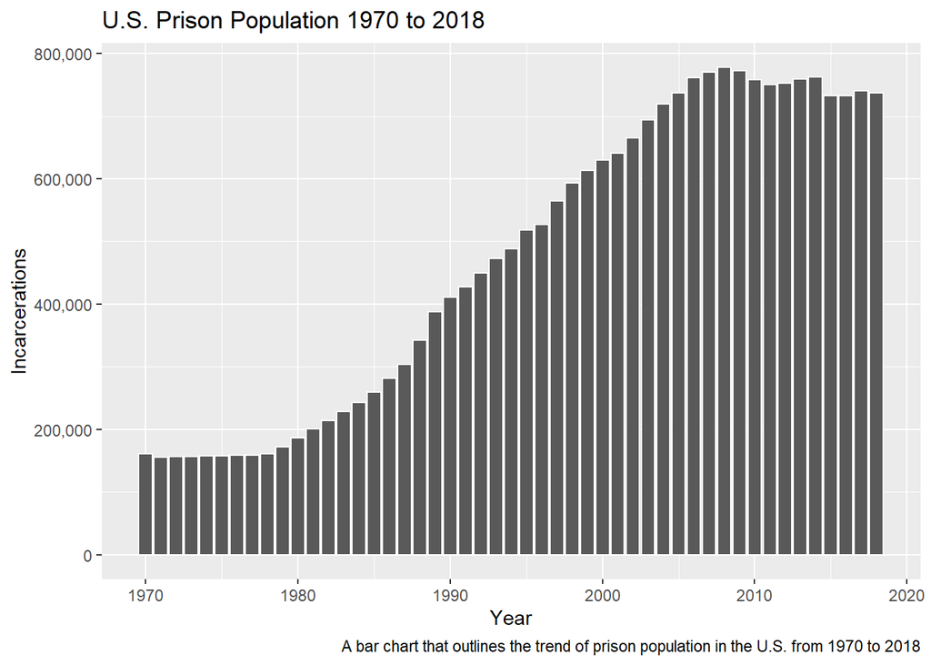

The bar chart of U.S. prison population from 1970 to 2018 expresses a continuous growth starting from around 1980 and peaking in 2008. The result of this growth has almost quadrupled the prison population from around 200,000 to almost 800,000. This sparks the question of **WHAT** happened during that growth interval and **HOW** can this massive but gradual increase of incarceration be contained?

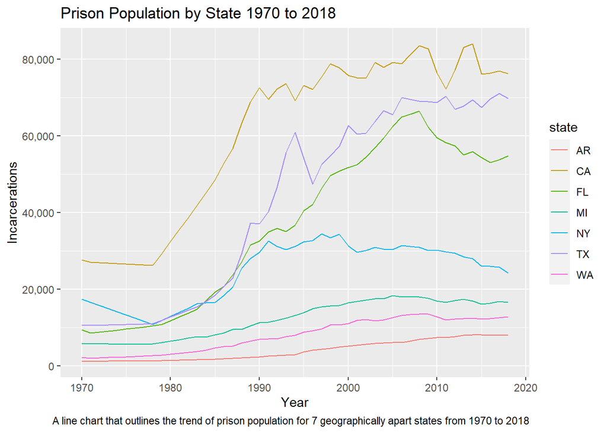

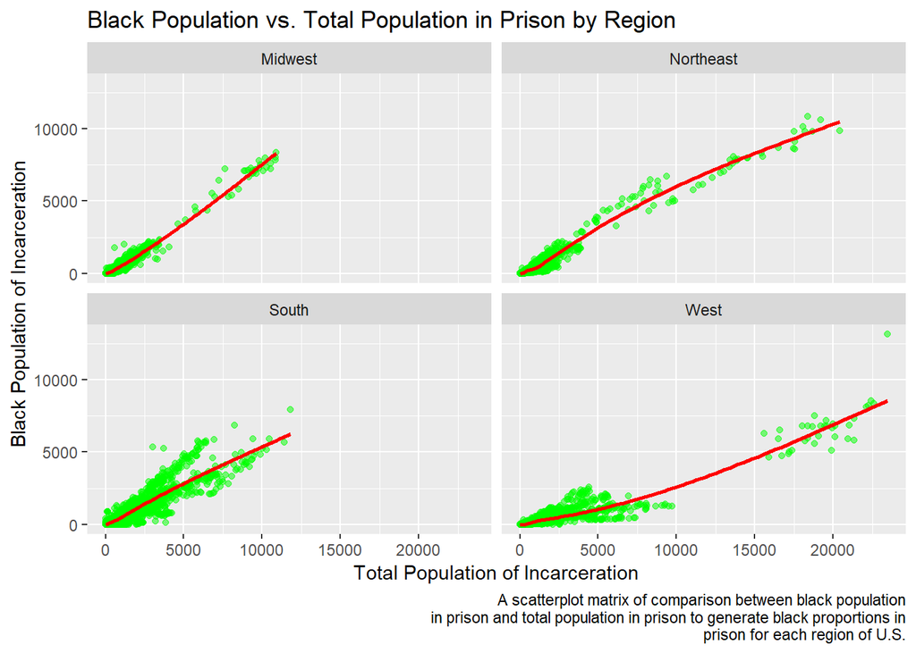

The scatterplot matrix of black population in prison compared to total prison population generates for each of the four regions. Each dot represents an observation based on year and fips. For each region, a line is drawn to visualize the slope. Whereas the steeper the slope of the line, the higher the proportion of blacks that were incarcerated. Each line per region are relatively straight which indicates that the size of a population does not affect the prison population proportion that are blacks. However, it is noticeable that *Midwest* has the steepest slope, hitting around 7,500 incarcerated blacks for 10,000 total incarcerated population, around **0.75** of blacks in prison. This sparks the question of **why** the difference in proportion between each regions as well as **what** is causing the high proportions of incarcerated blacks?

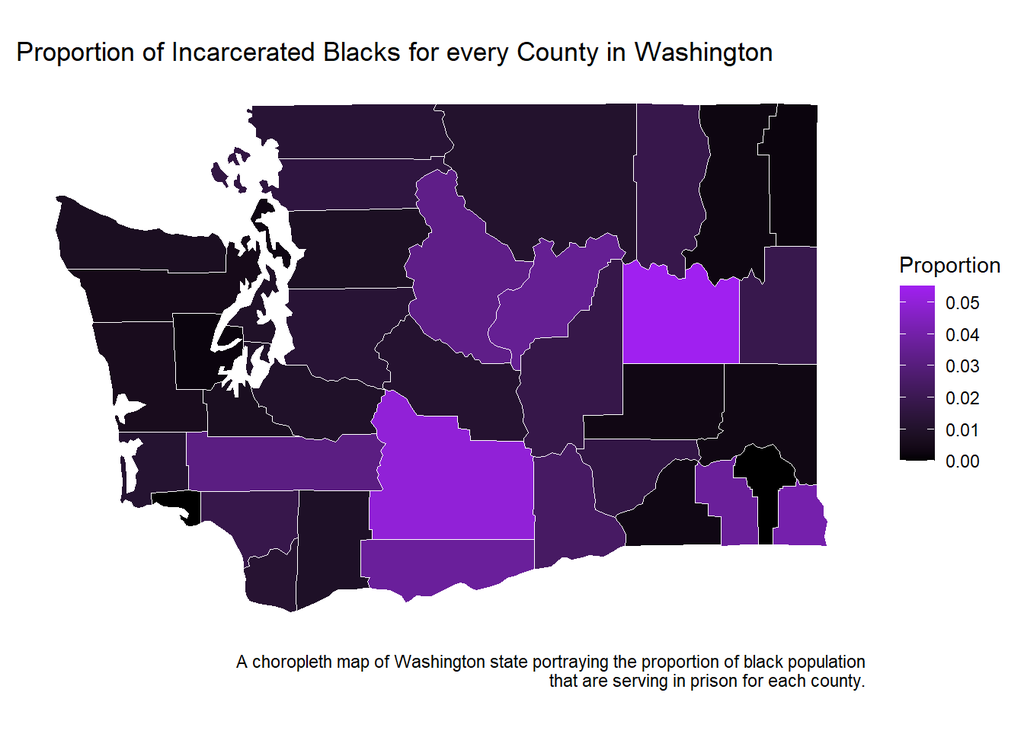

The choropleth map of Washington state takes the population of blacks in jail and the total black population to generate a ratio that indicates the concentration of blacks in prison for each county. It shows that counties near the pudget sound and the pacific ocean have the least concentration of incarcerated blacks whereas counties away from large bodies of water such as the south and east have higher concentration of incarcerated blacks. This sparks the questions of **what** policies each counties are enforcing that’s causing the disparities?